```python
import pandas as pd
import matplotlib.pyplot as plt
import spacy
```

# Stats for the Supervised Project

Axel FELTEN, Jinane HARCHAL, Mario JAKIMOSKI, Hao MENG

## Functions to plot our data

```python
def bar_plot_function_Fixed_axis(x, y, xlabel, ylabel, title):
    fig, ax = plt.subplots()
    ax.bar(x, y, width=1, edgecolor="white", linewidth=0.7)
    ax.set(ylim=(0, 650), xlabel=xlabel, ylabel=ylabel, title=title)
    ax.tick_params(axis='x', rotation=90)
    plt.grid()
    plt.show
```

```python
def bar_plot_function(x, y, xlabel, ylabel, title):
    fig, ax = plt.subplots()
    ax.bar(x, y, width=1, edgecolor="white", linewidth=0.7)
    ax.set(ylim=(0, max(y) + (max(y) * 0.1)), xlabel=xlabel, ylabel=ylabel, title=title)
    ax.tick_params(axis='x', rotation=90, labelsize=5)
    plt.grid()
    plt.show
```

# README

- To use this code, this file need to be in the same folder as th csv files.
- Be carefull on the file path indicated on every function.

# Files names: Preparation

```python
#This is a string with the name of every files from our corpus.
#Our corpus is a subcorpus from the BNC Corpus.

STR_corpus_names= "KE4_067607.xml KBK_002334.xml KBD_064002.xml KDE_007113.xml KBL_040501.xml KPW_133301.xml KE3_011211.xml KCD_005214.xml KSN_135904.xml KDA_011605.xml KDB_014817.xml KBE_009101.xml KC6_055905.xml KD2_061610.xml KPY_136604.xml KCE_029701.xml KD1_034501.xml KNV_137903.xml KDM_030302.xml KC6_055705.xml KRH_fixed_25.xml KRF_fixed_3.xml KRH_fixed_34.xml KRG_fixed_9.xml KRF_fixed_1.xml KRH_fixed_37.xml KRH_fixed_16.xml KRG_fixed_13.xml KRH_fixed_27.xml KRH_fixed_23.xml KRL_fixed_3.xml KJS.xml KS7_fixed_4.xml KGH.xml KRL_fixed_4.xml FL7.xml HV1.xml FLD.xml FLH.xml FL4.xml HF3.xml HV5.xml HEC.xml HE8.xml HV6.xml H5G.xml HES.xml HDJ.xml HEA.xml K69.xml G3U.xml J9D.xml JJG.xml J8D.xml KS0.xml KLV.xml J3T.xml JJ9.xml JN7.xml JJA.xml"
List_Files_Full = STR_corpus_names.split()
print("List of the names of the files")
print(List_Files_Full)
print("\n")
```

```
List of the names of the files
['KE4_067607.xml', 'KBK_002334.xml', 'KBD_064002.xml', 'KDE_007113.xml', 'KBL_040501.xml', 'KPW_133301.xml', 'KE3_011211.xml', 'KCD_005214.xml', 'KSN_135904.xml', 'KDA_011605.xml', 'KDB_014817.xml', 'KBE_009101.xml', 'KC6_055905.xml', 'KD2_061610.xml', 'KPY_136604.xml', 'KCE_029701.xml', 'KD1_034501…
```

## First subcategory: Dialogue/Multilogue

```python
def turn_str_into_list_files(str_names_files):
    result = []
    mid_list = str_names_files.split(" ")
    for files_names in mid_list:
        result.append(files_names+".xml")
    return(result)
```

```python
print("List of the files that are dialogue")
Dialogue = "KBE_009101 KRF_fixed_1 KRF_fixed_3 KRG_fixed_13 KRG_fixed_9 KRH_fixed_16 KRH_fixed_25 KRH_fixed_27 KRH_fixed_37 KRH_fixed_23 KRH_fixed_34 H5G HDJ HEC HF3 HV6 K69 KBD_064002 KBK_002334 KBL_040501 KE4_067607 KPW_133301 HE8 HEA HES HV5 KS7_fixed_4 KS0 KCD_005214 KDE_007113 KE3_011211 KSN_135904"
Dialogue_list = turn_str_into_list_files(Dialogue)
print(Dialogue_list)

print("\n")

print("List of files that are multilogue")
Multilogue = "G3U JN7 KLV J8D FL4 FL7 FLD FLH HV1 KC6_055705 KC6_055905 KCE_029701 KD1_034501 KD2_061610 KDA_011605 KDB_014817 KGH KJS KNV_137903 KRL_fixed_3 KRL_fixed_4 J3T J9D JJ9 JJA JJG KDM_030302 KPY_136604"
Multilogue_list = turn_str_into_list_files(Multilogue)
print(Multilogue_list)
```

```
List of the files that are dialogue
['KBE_009101.xml', 'KRF_fixed_1.xml', 'KRF_fixed_3.xml', 'KRG_fixed_13.xml', 'KRG_fixed_9.xml', 'KRH_fixed_16.xml', 'KRH_fixed_25.xml', 'KRH_fixed_27.xml', 'KRH_fixed_37.xml', 'KRH_fixed_23.xml', 'KRH_fixed_34.xml', 'H5G.xml', 'HDJ.xml', 'HEC.xml', 'HF3.xml', 'HV6.xml', 'K69.xml', 'KBD_064002.xml', …


List of files that are multilogue
['G3U.xml', 'JN7.xml', 'KLV.xml', 'J8D.xml', 'FL4.xml', 'FL7.xml', 'FLD.xml', 'FLH.xml', 'HV1.xml', 'KC6_055705.xml', 'KC6_055905.xml', 'KCE_029701.xml', 'KD1_034501.xml', 'KD2_061610.xml', 'KDA_011605.xml', 'KDB_014817.xml', 'KGH.xml', 'KJS.xml', 'KNV_137903.xml', 'KRL_fixed_3.xml', 'KRL_fixed_4.xm…
```

## Second subcategory: multilabels

```python
print("List of the files that are informative")
informative = "KRF_fixed_1 KRF_fixed_3 KRG_fixed_13 KRG_fixed_9 KRH_fixed_16 KRH_fixed_25 KRH_fixed_27 KRH_fixed_37 KRH_fixed_23 KRH_fixed_34 J8D"
informative_list = turn_str_into_list_files(informative)
print(informative_list)

print("\n")

print("List of the files that are leisure")
leisure = "H5G HDJ HEC HF3 HV6 K69 KBD_064002 KBK_002334 KBL_040501 KE4_067607 KPW_133301 HE8 HEA HES HV5 KS7_fixed_4 FL4 FL7 FLD FLH HV1 KC6_055705 KC6_055905 KCE_029701 KD1_034501 KD2_061610 KDA_011605 KDB_014817 KGH KJS KNV_137903 KRL_fixed_3 KRL_fixed_4"
leisure_list = turn_str_into_list_files(leisure)
print(leisure_list)

print("\n")

print("List of the files that are public")
public = "KS0 J3T J9D JJ9 JJA JJG"
public_list = turn_str_into_list_files(public)
print(public_list)

print("\n")

print("list of the files that are business")
business = "G3U JN7 KLV"
business_list = turn_str_into_list_files(business)
print(business_list)

print("\n")

print("List of the files that are unclassified")
unclassified = "KBE_009101 KCD_005214 KDE_007113 KE3_011211 KSN_135904 KDM_030302 KPY_136604"
unclassified_list = turn_str_into_list_files(unclassified)
print(unclassified_list)
```

```
List of the files that are informative
['KRF_fixed_1.xml', 'KRF_fixed_3.xml', 'KRG_fixed_13.xml', 'KRG_fixed_9.xml', 'KRH_fixed_16.xml', 'KRH_fixed_25.xml', 'KRH_fixed_27.xml', 'KRH_fixed_37.xml', 'KRH_fixed_23.xml', 'KRH_fixed_34.xml', 'J8D.xml']


List of the files that are leisure
['H5G.xml', 'HDJ.xml', 'HEC.xml', 'HF3.xml', 'HV6.xml', 'K69.xml', 'KBD_064002.xml', 'KBK_002334.xml', 'KBL_040501.xml', 'KE4_067607.xml', 'KPW_133301.xml', 'HE8.xml', 'HEA.xml', 'HES.xml', 'HV5.xml', 'KS7_fixed_4.xml', 'FL4.xml', 'FL7.xml', 'FLD.xml', 'FLH.xml', 'HV1.xml', 'KC6_055705.xml', 'KC6_05…


List of the files that are public
['KS0.xml', 'J3T.xml', 'J9D.xml', 'JJ9.xml', 'JJA.xml', 'JJG.xml']


list of the files that are business
['G3U.xml', 'JN7.xml', 'KLV.xml']


List of the files that are unclassified
['KBE_009101.xml', 'KCD_005214.xml', 'KDE_007113.xml', 'KE3_011211.xml', 'KSN_135904.xml', 'KDM_030302.xml', 'KPY_136604.xml']
```

## Third selection: Our reading of the files

```python
board_meeting_list = ["J9D.xml"]

print("List of the files that are broadcast discussion")
Broadcast_discussion = "KRF_fixed_3 KRH_fixed_25 KRH_fixed_27 FL4 FLH HV1 KGH FL7"
Broadcast_discussion_list = turn_str_into_list_files(Broadcast_discussion)
print(Broadcast_discussion_list)

print("\n")

business_meeting_list = ["KLV.xml"]

print("List of the committee meeting")
committee_meeting = "KS0 J3T JJ9 JJA"
committee_meeting_list = turn_str_into_list_files(committee_meeting)
print(committee_meeting_list)

print("\n")

print("list of the conversations")
conversation = "KBD_064002 KBK_002334 KBL_040501 KE4_067607 KPW_133301 KCD_005214 KDE_007113 KE3_011211 KC6_055705 KC6_055905 KCE_029701 KD1_034501 KD2_061610 KDA_011605 KDB_014817 KJS KNV_137903 KDM_030302 KPY_136604"
conversation_list = turn_str_into_list_files(conversation)
print(conversation_list)

print("\n")

group_meeting_list = ["G3U.xml"]

print("List of the interview")
interview = "H5G HDJ HEC HF3 HV6 K69 HE8 HEA HES"
interview_list = turn_str_into_list_files(interview)
print(interview_list)

print("\n")

print("List of the meeting")
meeting = "J8D JJG"
meeting_list = turn_str_into_list_files(meeting)
print(meeting_list)

print("\n")

print("Files that are Radio broadcast")
radio_broadcast = "KRF_fixed_1 KRG_fixed_13 KRG_fixed_9 KRH_fixed_16 KRH_fixed_37 KRH_fixed_23 KRH_fixed_34 HV5 KS7_fixed_4 KRL_fixed_3 KRL_fixed_4"
radio_broadcast_list = turn_str_into_list_files(radio_broadcast)
print(radio_broadcast_list)

print("\n")

sales_meeting_list = ["JN7.xml"]

tv_discussion_list= ["FLD.xml"]

print("unclassified")
unclassified_2 = "KBE_009101 KSN_135904"
unclassified_2_list = turn_str_into_list_files(unclassified_2)
print(unclassified_2_list)
```

```
List of the files that are broadcast discussion
['KRF_fixed_3.xml', 'KRH_fixed_25.xml', 'KRH_fixed_27.xml', 'FL4.xml', 'FLH.xml', 'HV1.xml', 'KGH.xml', 'FL7.xml']


List of the committee meeting
['KS0.xml', 'J3T.xml', 'JJ9.xml', 'JJA.xml']


list of the conversations
['KBD_064002.xml', 'KBK_002334.xml', 'KBL_040501.xml', 'KE4_067607.xml', 'KPW_133301.xml', 'KCD_005214.xml', 'KDE_007113.xml', 'KE3_011211.xml', 'KC6_055705.xml', 'KC6_055905.xml', 'KCE_029701.xml', 'KD1_034501.xml', 'KD2_061610.xml', 'KDA_011605.xml', 'KDB_014817.xml', 'KJS.xml', 'KNV_137903.xml', …


List of the interview
['H5G.xml', 'HDJ.xml', 'HEC.xml', 'HF3.xml', 'HV6.xml', 'K69.xml', 'HE8.xml', 'HEA.xml', 'HES.xml']


List of the meeting
['J8D.xml', 'JJG.xml']


Files that are Radio broadcast
['KRF_fixed_1.xml', 'KRG_fixed_13.xml', 'KRG_fixed_9.xml', 'KRH_fixed_16.xml', 'KRH_fixed_37.xml', 'KRH_fixed_23.xml', 'KRH_fixed_34.xml', 'HV5.xml', 'KS7_fixed_4.xml', 'KRL_fixed_3.xml', 'KRL_fixed_4.xml']


unclassified
['KBE_009101.xml', 'KSN_135904.xml']
```

# Graphs about Utterances Distribution inside the files

## Function for the graph

This function use our list of files names to convert them into the equivalent on CSV. To get the CSV files, we can use the "Convert_SpeakersU_CSV.py". But, for this file works, you need to get another file that count the number of Utterances per speakers, based on the txt files from our corpus clean. To use it, we need the file that was generated with the "count_utterance.py"

```python
def graph_utterances_distribution(files_list):
    csv_name = []
    #Get the files paths
    for file in files_list:
        csv_name.append(file.replace(".xml", "_clean.csv"))
        #We use this list as file path. Be carefull, you might want to add part of the file path.
        #This only work if this notebook is in the same folder as your CSV.
    csv_name.sort()

    #To plot the data in the CSV.
    for CSV_file in csv_name:
        data_frame = pd.read_csv("NB_Utterances_Per_Speakers/"+CSV_file) #The files paths to generate the number of utterances graph.
        data_frame_speakers = data_frame["speaker"]
        data_frame_utterances = data_frame["nb_utterances"]
        bar_plot_function(data_frame_speakers, data_frame_utterances, "Speakers", "Number of utterances", f"Number of utterances for each speaker in {CSV_file}")
    return(f"The graph about the utterances distribution for the {files_list} are done")
```

### Graphs for Utterances distribution, first classification

```python
print("For the dialogue")
print(graph_utterances_distribution(Dialogue_list))
```

```
For the dialogue
```

```
The graph about the utterances distribution for the ['KBE_009101.xml', 'KRF_fixed_1.xml', 'KRF_fixed_3.xml', 'KRG_fixed_13.xml', 'KRG_fixed_9.xml', 'KRH_fixed_16.xml', 'KRH_fixed_25.xml', 'KRH_fixed_27.xml', 'KRH_fixed_37.xml', 'KRH_fixed_23.xml', 'KRH_fixed_34.xml', 'H5G.xml', 'HDJ.xml', 'HEC.xml',…
```

```python
print("For the multilogue")
print(graph_utterances_distribution(Multilogue_list))
```

```
For the multilogue
```

```
The graph about the utterances distribution for the ['G3U.xml', 'JN7.xml', 'KLV.xml', 'J8D.xml', 'FL4.xml', 'FL7.xml', 'FLD.xml', 'FLH.xml', 'HV1.xml', 'KC6_055705.xml', 'KC6_055905.xml', 'KCE_029701.xml', 'KD1_034501.xml', 'KD2_061610.xml', 'KDA_011605.xml', 'KDB_014817.xml', 'KGH.xml', 'KJS.xml', …
```

### Graphs for Utterances distribution, second classification

```python
print("For the informative")
print(graph_utterances_distribution(informative_list))
```

```
For the informative
The graph about the utterances distribution for the ['KRF_fixed_1.xml', 'KRF_fixed_3.xml', 'KRG_fixed_13.xml', 'KRG_fixed_9.xml', 'KRH_fixed_16.xml', 'KRH_fixed_25.xml', 'KRH_fixed_27.xml', 'KRH_fixed_37.xml', 'KRH_fixed_23.xml', 'KRH_fixed_34.xml', 'J8D.xml'] are done
```

```python
print("for the leisure")
print(graph_utterances_distribution(leisure_list))
```

```
for the leisure
```

```
The graph about the utterances distribution for the ['H5G.xml', 'HDJ.xml', 'HEC.xml', 'HF3.xml', 'HV6.xml', 'K69.xml', 'KBD_064002.xml', 'KBK_002334.xml', 'KBL_040501.xml', 'KE4_067607.xml', 'KPW_133301.xml', 'HE8.xml', 'HEA.xml', 'HES.xml', 'HV5.xml', 'KS7_fixed_4.xml', 'FL4.xml', 'FL7.xml', 'FLD.x…
```

```python
print("For the public")
print(graph_utterances_distribution(public_list))
```

```
For the public
The graph about the utterances distribution for the ['KS0.xml', 'J3T.xml', 'J9D.xml', 'JJ9.xml', 'JJA.xml', 'JJG.xml'] are done
```

```python
print("For the business")
print(graph_utterances_distribution(business_list))
```

```
For the business
The graph about the utterances distribution for the ['G3U.xml', 'JN7.xml', 'KLV.xml'] are done
```

```python
print("For the unclassified")
print(graph_utterances_distribution(unclassified_list))
```

```
For the unclassified
The graph about the utterances distribution for the ['KBE_009101.xml', 'KCD_005214.xml', 'KDE_007113.xml', 'KE3_011211.xml', 'KSN_135904.xml', 'KDM_030302.xml', 'KPY_136604.xml'] are done
```

### Graphs for Utterances distribution, third classification

```python
print("For the board meeting")
print(graph_utterances_distribution(board_meeting_list))
```

```
For the board meeting
The graph about the utterances distribution for the ['J9D.xml'] are done
```

```python
print("for the broadcast discussion")
print(graph_utterances_distribution(Broadcast_discussion_list))
```

```
for the broadcast discussion
The graph about the utterances distribution for the ['KRF_fixed_3.xml', 'KRH_fixed_25.xml', 'KRH_fixed_27.xml', 'FL4.xml', 'FLH.xml', 'HV1.xml', 'KGH.xml', 'FL7.xml'] are done
```

```python
print("for the business meeting")
print(graph_utterances_distribution(business_meeting_list))
```

```
for the business meeting
The graph about the utterances distribution for the ['KLV.xml'] are done
```

```python
print("for the committee meeting")
print(graph_utterances_distribution(committee_meeting_list))
```

```
for the committee meeting
The graph about the utterances distribution for the ['KS0.xml', 'J3T.xml', 'JJ9.xml', 'JJA.xml'] are done
```

```python
print("for the conversation")
print(graph_utterances_distribution(conversation_list))
```

```
for the conversation
The graph about the utterances distribution for the ['KBD_064002.xml', 'KBK_002334.xml', 'KBL_040501.xml', 'KE4_067607.xml', 'KPW_133301.xml', 'KCD_005214.xml', 'KDE_007113.xml', 'KE3_011211.xml', 'KC6_055705.xml', 'KC6_055905.xml', 'KCE_029701.xml', 'KD1_034501.xml', 'KD2_061610.xml', 'KDA_011605.x…
```

```python
print("for the group meeting")
print(graph_utterances_distribution(group_meeting_list))
```

```
for the group meeting
The graph about the utterances distribution for the ['G3U.xml'] are done
```

```python
print("for the broadcast interview")
print(graph_utterances_distribution(interview_list))
```

```
for the broadcast interview
The graph about the utterances distribution for the ['H5G.xml', 'HDJ.xml', 'HEC.xml', 'HF3.xml', 'HV6.xml', 'K69.xml', 'HE8.xml', 'HEA.xml', 'HES.xml'] are done
```

```python
print("for the broadcast meeting")
print(graph_utterances_distribution(meeting_list))
```

```
for the broadcast meeting
The graph about the utterances distribution for the ['J8D.xml', 'JJG.xml'] are done
```

```python
print("for the broadcast radio broadcast")
print(graph_utterances_distribution(radio_broadcast_list))
```

```
for the broadcast radio broadcast
The graph about the utterances distribution for the ['KRF_fixed_1.xml', 'KRG_fixed_13.xml', 'KRG_fixed_9.xml', 'KRH_fixed_16.xml', 'KRH_fixed_37.xml', 'KRH_fixed_23.xml', 'KRH_fixed_34.xml', 'HV5.xml', 'KS7_fixed_4.xml', 'KRL_fixed_3.xml', 'KRL_fixed_4.xml'] are done
```

```python
print("for the broadcast sales meeting")
print(graph_utterances_distribution(sales_meeting_list))
```

```
for the broadcast sales meeting
The graph about the utterances distribution for the ['JN7.xml'] are done
```

```python
print("for the broadcast Tv discussion")
print(graph_utterances_distribution(tv_discussion_list))
```

```
for the broadcast Tv discussion
The graph about the utterances distribution for the ['FLD.xml'] are done
```

```python
print("for the broadcast unclassified")
print(graph_utterances_distribution(unclassified_2_list))
```

```
for the broadcast unclassified
The graph about the utterances distribution for the ['KBE_009101.xml', 'KSN_135904.xml'] are done
```

# Graphs about the length of the utterances per speakers of all the corpus

This next function read the files that were cleaned. So be carefull about the file path To get those files, we use the parser that we created to keep only the text from the xml files.

```python
def check_utterances(file):
    nlp = spacy.load("en_core_web_sm")
    dict_speakers_nb_tokens = {}
    with open(file) as f:
        content_file = f.readlines()

        while "[" not in content_file[0]:
            content_file.pop(0)
        for line in content_file:
            list_from_line = line.split()
            list_from_line.pop(0)
            speakers = list_from_line.pop(0)
            Ligne_from_file = nlp(line)

            if speakers in dict_speakers_nb_tokens:
                dict_speakers_nb_tokens[speakers] = dict_speakers_nb_tokens[speakers] + len(Ligne_from_file)-5
            else:
                dict_speakers_nb_tokens[speakers] = len(Ligne_from_file)-5 #Because 5 elements are in addition that we don't want to take into account
    return (dict_speakers_nb_tokens)

def check_utterances_plot(files_list):
    #to get the filepath of every file. This notebook need to be in the same folder as the files.
    txt_name_full = []
    for file in files_list:
        txt_name_full.append(file.replace(".xml", "_clean.txt"))
    txt_name_full.sort()
    i = 0
    for fichier in txt_name_full:
        i+=1
        file_path = "Corpus_Clean/"+fichier #The file path with the corpus cleaned txt file.
        print("\n")
        print(file_path)
        print(f"{i}/{len(files_list)}")
        dict_length_utterance = check_utterances(file_path)
        print(dict_length_utterance)
        bar_plot_function(dict_length_utterance.keys(), dict_length_utterance.values(), "Speakers", "Length of utterances", f"Length of utterances for each speaker in {fichier}")
    return(f"The graph about the utterances length for the {files_list} are done")
```

## Graphs for Utterances length, first classification

```python
print("For the dialogue")
print(check_utterances_plot(Dialogue_list))
```

```
For the dialogue


Corpus_Clean/H5G_clean.txt
1/32
{'PS22C:': 3810, 'PS22D:': 17406}


Corpus_Clean/HDJ_clean.txt
2/32
{'PS22G:': 1649, 'PS22H:': 8555}


Corpus_Clean/HE8_clean.txt
3/32
{'PS2UP:': 1659, 'PS2UR:': 6085}


Corpus_Clean/HEA_clean.txt
4/32
{'PS2UV:': 646, 'PS2UW:': 3362}


Corpus_Clean/HEC_clean.txt
5/32
{'PS2UX:': 2965, 'PS2UY:': 336}


Corpus_Clean/HES_clean.txt
6/32
{'PS2W0:': 9211, 'PS2W1:': 375}


Corpus_Clean/HF3_clean.txt
7/32
{'PS2Y5:': 11264, 'PS2Y6:': 619}


Corpus_Clean/HV5_clean.txt
8/32
```

[output cut: 55 more lines]

```
{'PS58J:': 243, 'PS58H:': 158}


Corpus_Clean/KRF_fixed_1_clean.txt
20/32
{'PS5RL:': 526, 'PS5RM:': 2149}


Corpus_Clean/KRF_fixed_3_clean.txt
21/32
{'PS5RS:': 927, 'PS5RT:': 2183}


Corpus_Clean/KRG_fixed_13_clean.txt
22/32
```

```
{'PS5SC:': 500, 'PS5SE:': 2218}


Corpus_Clean/KRG_fixed_9_clean.txt
23/32
{'KRGPSUNK:': 482, 'PS5S7:': 2029}


Corpus_Clean/KRH_fixed_16_clean.txt
24/32
{'PS5T8:': 375, 'PS5TE:': 2348}


Corpus_Clean/KRH_fixed_23_clean.txt
25/32
{'PS5T8:': 531, 'PS5TC:': 2168}


Corpus_Clean/KRH_fixed_25_clean.txt
26/32
{'PS5T8:': 453, 'PS5TE:': 2365}


Corpus_Clean/KRH_fixed_27_clean.txt
27/32
{'PS5T8:': 613, 'PS5TG:': 2242}


Corpus_Clean/KRH_fixed_34_clean.txt
28/32
{'PS5TC:': 472, 'PS5TF:': 2119}


Corpus_Clean/KRH_fixed_37_clean.txt
29/32
{'PS5TE:': 347, 'PS5TA:': 3919}


Corpus_Clean/KS0_clean.txt
30/32
{'PS6H7:': 104, 'PS6H8:': 531, 'PS6H9:': 1761, 'PS6HA:': 460, 'PS6HB:': 116, 'PS6HC:': 966, 'PS6HD:': 669, 'PS6HE:': 1084, 'PS6HF:': 3401, 'PS6HG:': 3145, 'PS6HH:': 124, 'PS6HJ:': 13, 'PS6HK:': 940, 'PS6HL:': 124}


Corpus_Clean/KS7_fixed_4_clean.txt
31/32
{'PS6KR:': 2013, 'PS6KV:': 1890, 'PS6KT:': 1021, 'PS6LP:': 363, 'PS6LR:': 285, 'PS6L1:': 525, 'PS6KY:': 365, 'PS6LK:': 348, 'PS6LC:': 316, 'PS6LS:': 255, 'PS6LT:': 321, 'PS6LU:': 615, 'PS6LD:': 824, 'PS6L7:': 461, 'PS6KS:': 201, 'PS6L0:': 940, 'PS6LV:': 371, 'PS6LW:': 28, 'PS6LX:': 555}


Corpus_Clean/KSN_135904_clean.txt
32/32
{'PS6NV:': 41, 'KSNPSUNK:': 226}
The graph about the utterances length for the ['KBE_009101.xml', 'KRF_fixed_1.xml', 'KRF_fixed_3.xml', 'KRG_fixed_13.xml', 'KRG_fixed_9.xml', 'KRH_fixed_16.xml', 'KRH_fixed_25.xml', 'KRH_fixed_27.xml', 'KRH_fixed_37.xml', 'KRH_fixed_23.xml', 'KRH_fixed_34.xml', 'H5G.xml', 'HDJ.xml', 'HEC.xml', 'HF3.…
```

```python
print("For the multilogue")
print(check_utterances_plot(Multilogue_list))
```

```
For the multilogue


Corpus_Clean/FL4_clean.txt
1/28
{'FL4PSUNK:': 1134, 'FL4PS000:': 1865, 'FL4PS001:': 301, 'FL4PS002:': 370, 'FL4PS003:': 479, 'FL4PS004:': 419, 'FL4PS005:': 319, 'FL4PS006:': 504, 'FL4PS007:': 406, 'FL4PS008:': 321}


Corpus_Clean/FL7_clean.txt
2/28
{'FL7PSUNK:': 513, 'FL7PS000:': 1894, 'FL7PS001:': 519, 'FL7PS002:': 1018, 'FL7PS003:': 488, 'FL7PS004:': 815, 'FL7PS005:': 479, 'FL7PS006:': 301, 'FL7PS007:': 220, 'FL7PS008:': 396}


Corpus_Clean/FLD_clean.txt
3/28
{'FLDPSUNK:': 666, 'FLDPS000:': 1933, 'FLDPS001:': 690, 'FLDPS002:': 258, 'FLDPS003:': 756, 'FLDPS004:': 444, 'FLDPS005:': 248, 'FLDPS006:': 339, 'FLDPS007:': 220, 'FLDPS008:': 472}


Corpus_Clean/FLH_clean.txt
4/28
{'FLHPSUNK:': 823, 'FLHPS000:': 1736, 'FLHPS001:': 392, 'FLHPS002:': 401, 'FLHPS003:': 321, 'FLHPS004:': 271, 'FLHPS005:': 447, 'FLHPS006:': 1142, 'FLHPS007:': 441, 'FLHPS008:': 447}


Corpus_Clean/G3U_clean.txt
5/28
{'PS1VH:': 5135, 'G3UPSUNK:': 2034, 'PS1VJ:': 7116, 'G3UPS000:': 1770, 'G3UPS001:': 229, 'G3UPS002:': 1121, 'G3UPS003:': 398, 'G3UPS004:': 326, 'G3UPS005:': 379, 'G3UPS006:': 14}


Corpus_Clean/HV1_clean.txt
6/28
{'PS3E3:': 394, 'HV1PSUNK:': 1886, 'PS3E4:': 1437, 'PS3E5:': 535, 'PS3E6:': 978, 'PS3E7:': 118, 'PS3E8:': 833, 'PS3E9:': 653, 'PS3EA:': 171, 'PS3EB:': 181}


Corpus_Clean/J3T_clean.txt
7/28
{'J3TPSUNK:': 4568, 'PS3NV:': 1974, 'PS3NS:': 2318, 'PS3NT:': 471, 'PS3NW:': 632, 'J3TPS000:': 85, 'PS3NU:': 3229}


Corpus_Clean/J8D_clean.txt
8/28
```

[output cut: 55 more lines]

```
{'PS1GE:': 1284, 'PS1GF:': 92}


Corpus_Clean/KDB_014817_clean.txt
20/28
{'PS0KY:': 130, 'KDBPSUGP:': 12, 'PS0L1:': 12, 'KDBPSUNK:': 120, 'PS0L2:': 22, 'PS0L6:': 143}


Corpus_Clean/KDM_030302_clean.txt
21/28
{'PS0RE:': 123, 'PS0PN:': 268, 'KDMPSUGP:': 72, 'PS0RC:': 43, 'PS0RF:': 11}


Corpus_Clean/KGH_clean.txt
22/28
```

```
{'KGHPSUNK:': 4907, 'PS389:': 735, 'PS388:': 2159, 'PS38A:': 662, 'PS38B:': 373, 'PS38C:': 1315, 'PS38D:': 143, 'PS38E:': 267, 'PS38F:': 8459, 'PS38G:': 1911}


Corpus_Clean/KJS_clean.txt
23/28
{'KJSPSUNK:': 267, 'KJSPS001:': 476, 'KJSPS000:': 2710, 'KJSPS002:': 2988, 'KJSPS003:': 267, 'KJSPS004:': 272, 'KJSPS005:': 366, 'KJSPS006:': 586, 'KJSPS007:': 248, 'KJSPS008:': 549, 'KJSPS009:': 670, 'KJSPS00A:': 527, 'KJSPS00B:': 267, 'KJSPS00C:': 392, 'KJSPS00D:': 239, 'KJSPS00E:': 121, 'KJSPS00F…


Corpus_Clean/KLV_clean.txt
24/28
{'KLVPSUNK:': 6603, 'PS3SF:': 11647, 'PS3SG:': 814, 'PS3SH:': 787, 'PS3SJ:': 124, 'PS3SK:': 440, 'PS3SL:': 1041, 'PS3SM:': 51, 'PS3SN:': 103}


Corpus_Clean/KNV_137903_clean.txt
25/28
{'PS4Y3:': 339, 'KNVPS000:': 8, 'PS4Y5:': 6, 'PS4Y8:': 92, 'PS4Y4:': 36}


Corpus_Clean/KPY_136604_clean.txt
26/28
{'KPYPSUNK:': 73, 'PS58U:': 480, 'PS5AN:': 5, 'PS58Y:': 27, 'PS591:': 98, 'KPYPSUGP:': 40}


Corpus_Clean/KRL_fixed_3_clean.txt
27/28
{'PS5VN:': 1701, 'PS5VU:': 4070, 'PS5VV:': 801, 'KRLPSUNK:': 864, 'PS5VL:': 921, 'PS5VM:': 220}


Corpus_Clean/KRL_fixed_4_clean.txt
28/28
{'PS5VN:': 5086, 'PS5VP:': 185, 'PS5VR:': 209, 'PS5VS:': 2115, 'PS5VT:': 2540}
The graph about the utterances length for the ['G3U.xml', 'JN7.xml', 'KLV.xml', 'J8D.xml', 'FL4.xml', 'FL7.xml', 'FLD.xml', 'FLH.xml', 'HV1.xml', 'KC6_055705.xml', 'KC6_055905.xml', 'KCE_029701.xml', 'KD1_034501.xml', 'KD2_061610.xml', 'KDA_011605.xml', 'KDB_014817.xml', 'KGH.xml', 'KJS.xml', 'KNV_1…
```

## Graphs for Utterances length, second classification

```python
print("For the informative")
print(check_utterances_plot(informative_list))
```

```
For the informative


Corpus_Clean/J8D_clean.txt
1/11
{'PS3S7:': 8289, 'J8DPS004:': 3224, 'J8DPSUNK:': 7991, 'J8DPS000:': 3957, 'J8DPS001:': 3336, 'J8DPS002:': 2633, 'J8DPS003:': 1463}


Corpus_Clean/KRF_fixed_1_clean.txt
2/11
{'PS5RL:': 526, 'PS5RM:': 2149}


Corpus_Clean/KRF_fixed_3_clean.txt
3/11
{'PS5RS:': 927, 'PS5RT:': 2183}


Corpus_Clean/KRG_fixed_13_clean.txt
4/11
{'PS5SC:': 500, 'PS5SE:': 2218}


Corpus_Clean/KRG_fixed_9_clean.txt
5/11
{'KRGPSUNK:': 482, 'PS5S7:': 2029}


Corpus_Clean/KRH_fixed_16_clean.txt
6/11
{'PS5T8:': 375, 'PS5TE:': 2348}


Corpus_Clean/KRH_fixed_23_clean.txt
7/11
{'PS5T8:': 531, 'PS5TC:': 2168}


Corpus_Clean/KRH_fixed_25_clean.txt
8/11
{'PS5T8:': 453, 'PS5TE:': 2365}


Corpus_Clean/KRH_fixed_27_clean.txt
9/11
{'PS5T8:': 613, 'PS5TG:': 2242}


Corpus_Clean/KRH_fixed_34_clean.txt
10/11
{'PS5TC:': 472, 'PS5TF:': 2119}


Corpus_Clean/KRH_fixed_37_clean.txt
11/11
{'PS5TE:': 347, 'PS5TA:': 3919}
The graph about the utterances length for the ['KRF_fixed_1.xml', 'KRF_fixed_3.xml', 'KRG_fixed_13.xml', 'KRG_fixed_9.xml', 'KRH_fixed_16.xml', 'KRH_fixed_25.xml', 'KRH_fixed_27.xml', 'KRH_fixed_37.xml', 'KRH_fixed_23.xml', 'KRH_fixed_34.xml', 'J8D.xml'] are done
```

```python
print("for the leisure")
print(check_utterances_plot(leisure_list))
```

```
for the leisure


Corpus_Clean/FL4_clean.txt
1/33
{'FL4PSUNK:': 1134, 'FL4PS000:': 1865, 'FL4PS001:': 301, 'FL4PS002:': 370, 'FL4PS003:': 479, 'FL4PS004:': 419, 'FL4PS005:': 319, 'FL4PS006:': 504, 'FL4PS007:': 406, 'FL4PS008:': 321}


Corpus_Clean/FL7_clean.txt
2/33
{'FL7PSUNK:': 513, 'FL7PS000:': 1894, 'FL7PS001:': 519, 'FL7PS002:': 1018, 'FL7PS003:': 488, 'FL7PS004:': 815, 'FL7PS005:': 479, 'FL7PS006:': 301, 'FL7PS007:': 220, 'FL7PS008:': 396}


Corpus_Clean/FLD_clean.txt
3/33
{'FLDPSUNK:': 666, 'FLDPS000:': 1933, 'FLDPS001:': 690, 'FLDPS002:': 258, 'FLDPS003:': 756, 'FLDPS004:': 444, 'FLDPS005:': 248, 'FLDPS006:': 339, 'FLDPS007:': 220, 'FLDPS008:': 472}


Corpus_Clean/FLH_clean.txt
4/33
{'FLHPSUNK:': 823, 'FLHPS000:': 1736, 'FLHPS001:': 392, 'FLHPS002:': 401, 'FLHPS003:': 321, 'FLHPS004:': 271, 'FLHPS005:': 447, 'FLHPS006:': 1142, 'FLHPS007:': 441, 'FLHPS008:': 447}


Corpus_Clean/H5G_clean.txt
5/33
{'PS22C:': 3810, 'PS22D:': 17406}


Corpus_Clean/HDJ_clean.txt
6/33
{'PS22G:': 1649, 'PS22H:': 8555}


Corpus_Clean/HE8_clean.txt
7/33
{'PS2UP:': 1659, 'PS2UR:': 6085}


Corpus_Clean/HEA_clean.txt
8/33
```

[output cut: 55 more lines]

```
{'KC6PSUNK:': 11, 'PS0BA:': 118, 'PS0BF:': 113, 'PS0BG:': 297, 'PS0BB:': 4}


Corpus_Clean/KC6_055905_clean.txt
20/33
{'PS0BA:': 367, 'PS0BG:': 179, 'PS0BH:': 109, 'PS0BC:': 95, 'PS0BF:': 36, 'KC6PSUGP:': 43, 'PS0BJ:': 38, 'KC6PSUNK:': 12}


Corpus_Clean/KCE_029701_clean.txt
21/33
{'PS0EH:': 279, 'PS0ED:': 138, 'KCEPSUNK:': 32, 'PS0EE:': 27, 'PS0EB:': 117}


Corpus_Clean/KD1_034501_clean.txt
22/33
```

```
{'PS0JA:': 352, 'PS0JD:': 113, 'PS0JE:': 15, 'KD1PSUNK:': 57, 'PS0JB:': 74, 'PS0JF:': 23}


Corpus_Clean/KD2_061610_clean.txt
23/33
{'PS0J1:': 132, 'PS0J3:': 75, 'PS0J7:': 101, 'KD2PSUNK:': 3, 'PS0J4:': 209}


Corpus_Clean/KDA_011605_clean.txt
24/33
{'PS1GE:': 1284, 'PS1GF:': 92}


Corpus_Clean/KDB_014817_clean.txt
25/33
{'PS0KY:': 130, 'KDBPSUGP:': 12, 'PS0L1:': 12, 'KDBPSUNK:': 120, 'PS0L2:': 22, 'PS0L6:': 143}


Corpus_Clean/KE4_067607_clean.txt
26/33
{'PS0WN:': 332, 'PS0WS:': 176}


Corpus_Clean/KGH_clean.txt
27/33
{'KGHPSUNK:': 4907, 'PS389:': 735, 'PS388:': 2159, 'PS38A:': 662, 'PS38B:': 373, 'PS38C:': 1315, 'PS38D:': 143, 'PS38E:': 267, 'PS38F:': 8459, 'PS38G:': 1911}


Corpus_Clean/KJS_clean.txt
28/33
{'KJSPSUNK:': 267, 'KJSPS001:': 476, 'KJSPS000:': 2710, 'KJSPS002:': 2988, 'KJSPS003:': 267, 'KJSPS004:': 272, 'KJSPS005:': 366, 'KJSPS006:': 586, 'KJSPS007:': 248, 'KJSPS008:': 549, 'KJSPS009:': 670, 'KJSPS00A:': 527, 'KJSPS00B:': 267, 'KJSPS00C:': 392, 'KJSPS00D:': 239, 'KJSPS00E:': 121, 'KJSPS00F…


Corpus_Clean/KNV_137903_clean.txt
29/33
{'PS4Y3:': 339, 'KNVPS000:': 8, 'PS4Y5:': 6, 'PS4Y8:': 92, 'PS4Y4:': 36}


Corpus_Clean/KPW_133301_clean.txt
30/33
{'PS58J:': 243, 'PS58H:': 158}


Corpus_Clean/KRL_fixed_3_clean.txt
31/33
{'PS5VN:': 1701, 'PS5VU:': 4070, 'PS5VV:': 801, 'KRLPSUNK:': 864, 'PS5VL:': 921, 'PS5VM:': 220}


Corpus_Clean/KRL_fixed_4_clean.txt
32/33
{'PS5VN:': 5086, 'PS5VP:': 185, 'PS5VR:': 209, 'PS5VS:': 2115, 'PS5VT:': 2540}


Corpus_Clean/KS7_fixed_4_clean.txt
33/33
{'PS6KR:': 2013, 'PS6KV:': 1890, 'PS6KT:': 1021, 'PS6LP:': 363, 'PS6LR:': 285, 'PS6L1:': 525, 'PS6KY:': 365, 'PS6LK:': 348, 'PS6LC:': 316, 'PS6LS:': 255, 'PS6LT:': 321, 'PS6LU:': 615, 'PS6LD:': 824, 'PS6L7:': 461, 'PS6KS:': 201, 'PS6L0:': 940, 'PS6LV:': 371, 'PS6LW:': 28, 'PS6LX:': 555}
The graph about the utterances length for the ['H5G.xml', 'HDJ.xml', 'HEC.xml', 'HF3.xml', 'HV6.xml', 'K69.xml', 'KBD_064002.xml', 'KBK_002334.xml', 'KBL_040501.xml', 'KE4_067607.xml', 'KPW_133301.xml', 'HE8.xml', 'HEA.xml', 'HES.xml', 'HV5.xml', 'KS7_fixed_4.xml', 'FL4.xml', 'FL7.xml', 'FLD.xml', '…
```

```python
print("For the public")
print(check_utterances_plot(public_list))
```

```
For the public


Corpus_Clean/J3T_clean.txt
1/6
{'J3TPSUNK:': 4568, 'PS3NV:': 1974, 'PS3NS:': 2318, 'PS3NT:': 471, 'PS3NW:': 632, 'J3TPS000:': 85, 'PS3NU:': 3229}


Corpus_Clean/J9D_clean.txt
2/6
{'J9DPSUNK:': 5656, 'PS3V9:': 3731, 'PS3VA:': 606, 'PS3VB:': 904, 'PS3VC:': 3339, 'PS3VD:': 1874, 'PS3VE:': 717, 'PS3VF:': 331, 'PS3VG:': 1051, 'PS3VH:': 961}


Corpus_Clean/JJ9_clean.txt
3/6
{'JJ9PSUNK:': 4297, 'PS44C:': 477, 'PS44B:': 754, 'PS44D:': 2748, 'PS44F:': 113, 'PS44G:': 75, 'PS44H:': 316, 'PS44J:': 2515, 'PS44K:': 2486}


Corpus_Clean/JJA_clean.txt
4/6
{'JJAPSUNK:': 5240, 'PS44T:': 1855, 'PS450:': 1153, 'PS44U:': 387, 'PS44V:': 2179, 'PS44W:': 485, 'PS44X:': 16, 'PS44Y:': 560, 'PS44R:': 839, 'PS44S:': 932}


Corpus_Clean/JJG_clean.txt
5/6
{'JJGPSUNK:': 5882, 'PS45P:': 1365, 'PS45R:': 390, 'PS45S:': 5387, 'PS45T:': 3042, 'PS45U:': 2645, 'PS45V:': 767, 'PS45W:': 3541, 'PS45X:': 533, 'PS45Y:': 222}


Corpus_Clean/KS0_clean.txt
6/6
{'PS6H7:': 104, 'PS6H8:': 531, 'PS6H9:': 1761, 'PS6HA:': 460, 'PS6HB:': 116, 'PS6HC:': 966, 'PS6HD:': 669, 'PS6HE:': 1084, 'PS6HF:': 3401, 'PS6HG:': 3145, 'PS6HH:': 124, 'PS6HJ:': 13, 'PS6HK:': 940, 'PS6HL:': 124}
The graph about the utterances length for the ['KS0.xml', 'J3T.xml', 'J9D.xml', 'JJ9.xml', 'JJA.xml', 'JJG.xml'] are done
```

```python
print("For the business")
print(check_utterances_plot(business_list))
```

```
For the business


Corpus_Clean/G3U_clean.txt
1/3
{'PS1VH:': 5135, 'G3UPSUNK:': 2034, 'PS1VJ:': 7116, 'G3UPS000:': 1770, 'G3UPS001:': 229, 'G3UPS002:': 1121, 'G3UPS003:': 398, 'G3UPS004:': 326, 'G3UPS005:': 379, 'G3UPS006:': 14}


Corpus_Clean/JN7_clean.txt
2/3
{'JN7PSUNK:': 946, 'PS4BS:': 3360, 'PS4BP:': 83, 'PS4BR:': 47, 'PS4BT:': 1503, 'PS4BU:': 1765}


Corpus_Clean/KLV_clean.txt
3/3
{'KLVPSUNK:': 6603, 'PS3SF:': 11647, 'PS3SG:': 814, 'PS3SH:': 787, 'PS3SJ:': 124, 'PS3SK:': 440, 'PS3SL:': 1041, 'PS3SM:': 51, 'PS3SN:': 103}
The graph about the utterances length for the ['G3U.xml', 'JN7.xml', 'KLV.xml'] are done
```

```python
print("For the unclassified")
print(check_utterances_plot(unclassified_list))
```

```
For the unclassified


Corpus_Clean/KBE_009101_clean.txt
1/7
{'PS04F:': 338, 'PS04B:': 38, 'PS04E:': 122, 'PS04G:': 29, 'PS04D:': 72, 'PS04C:': 24, 'KBEPSUNK:': 36}


Corpus_Clean/KCD_005214_clean.txt
2/7
{'PS0E8:': 435, 'PS6ST:': 106}


Corpus_Clean/KDE_007113_clean.txt
3/7
{'PS0M4:': 340, 'PS13T:': 99}


Corpus_Clean/KDM_030302_clean.txt
4/7
{'PS0RE:': 123, 'PS0PN:': 268, 'KDMPSUGP:': 72, 'PS0RC:': 43, 'PS0RF:': 11}


Corpus_Clean/KE3_011211_clean.txt
5/7
{'PS0V5:': 248, 'PS0V4:': 148}


Corpus_Clean/KPY_136604_clean.txt
6/7
{'KPYPSUNK:': 73, 'PS58U:': 480, 'PS5AN:': 5, 'PS58Y:': 27, 'PS591:': 98, 'KPYPSUGP:': 40}


Corpus_Clean/KSN_135904_clean.txt
7/7
{'PS6NV:': 41, 'KSNPSUNK:': 226}
The graph about the utterances length for the ['KBE_009101.xml', 'KCD_005214.xml', 'KDE_007113.xml', 'KE3_011211.xml', 'KSN_135904.xml', 'KDM_030302.xml', 'KPY_136604.xml'] are done
```

## Graphs for Utterances length, third classification

```python
print("For the board meeting")
print(check_utterances_plot(board_meeting_list))
```

```
For the board meeting


Corpus_Clean/J9D_clean.txt
1/1
{'J9DPSUNK:': 5656, 'PS3V9:': 3731, 'PS3VA:': 606, 'PS3VB:': 904, 'PS3VC:': 3339, 'PS3VD:': 1874, 'PS3VE:': 717, 'PS3VF:': 331, 'PS3VG:': 1051, 'PS3VH:': 961}
The graph about the utterances length for the ['J9D.xml'] are done
```

```python
print("for the broadcast discussion")
print(check_utterances_plot(Broadcast_discussion_list))
```

```
for the broadcast discussion


Corpus_Clean/FL4_clean.txt
1/8
{'FL4PSUNK:': 1134, 'FL4PS000:': 1865, 'FL4PS001:': 301, 'FL4PS002:': 370, 'FL4PS003:': 479, 'FL4PS004:': 419, 'FL4PS005:': 319, 'FL4PS006:': 504, 'FL4PS007:': 406, 'FL4PS008:': 321}


Corpus_Clean/FL7_clean.txt
2/8
{'FL7PSUNK:': 513, 'FL7PS000:': 1894, 'FL7PS001:': 519, 'FL7PS002:': 1018, 'FL7PS003:': 488, 'FL7PS004:': 815, 'FL7PS005:': 479, 'FL7PS006:': 301, 'FL7PS007:': 220, 'FL7PS008:': 396}


Corpus_Clean/FLH_clean.txt
3/8
{'FLHPSUNK:': 823, 'FLHPS000:': 1736, 'FLHPS001:': 392, 'FLHPS002:': 401, 'FLHPS003:': 321, 'FLHPS004:': 271, 'FLHPS005:': 447, 'FLHPS006:': 1142, 'FLHPS007:': 441, 'FLHPS008:': 447}


Corpus_Clean/HV1_clean.txt
4/8
{'PS3E3:': 394, 'HV1PSUNK:': 1886, 'PS3E4:': 1437, 'PS3E5:': 535, 'PS3E6:': 978, 'PS3E7:': 118, 'PS3E8:': 833, 'PS3E9:': 653, 'PS3EA:': 171, 'PS3EB:': 181}


Corpus_Clean/KGH_clean.txt
5/8
{'KGHPSUNK:': 4907, 'PS389:': 735, 'PS388:': 2159, 'PS38A:': 662, 'PS38B:': 373, 'PS38C:': 1315, 'PS38D:': 143, 'PS38E:': 267, 'PS38F:': 8459, 'PS38G:': 1911}


Corpus_Clean/KRF_fixed_3_clean.txt
6/8
{'PS5RS:': 927, 'PS5RT:': 2183}


Corpus_Clean/KRH_fixed_25_clean.txt
7/8
{'PS5T8:': 453, 'PS5TE:': 2365}


Corpus_Clean/KRH_fixed_27_clean.txt
8/8
{'PS5T8:': 613, 'PS5TG:': 2242}
The graph about the utterances length for the ['KRF_fixed_3.xml', 'KRH_fixed_25.xml', 'KRH_fixed_27.xml', 'FL4.xml', 'FLH.xml', 'HV1.xml', 'KGH.xml', 'FL7.xml'] are done
```

```python
print("for the business meeting")
print(check_utterances_plot(business_meeting_list))
```

```
for the business meeting


Corpus_Clean/KLV_clean.txt
1/1
{'KLVPSUNK:': 6603, 'PS3SF:': 11647, 'PS3SG:': 814, 'PS3SH:': 787, 'PS3SJ:': 124, 'PS3SK:': 440, 'PS3SL:': 1041, 'PS3SM:': 51, 'PS3SN:': 103}
The graph about the utterances length for the ['KLV.xml'] are done
```

```python
print("for the committee meeting")
print(check_utterances_plot(committee_meeting_list))
```

```
for the committee meeting


Corpus_Clean/J3T_clean.txt
1/4
{'J3TPSUNK:': 4568, 'PS3NV:': 1974, 'PS3NS:': 2318, 'PS3NT:': 471, 'PS3NW:': 632, 'J3TPS000:': 85, 'PS3NU:': 3229}


Corpus_Clean/JJ9_clean.txt
2/4
{'JJ9PSUNK:': 4297, 'PS44C:': 477, 'PS44B:': 754, 'PS44D:': 2748, 'PS44F:': 113, 'PS44G:': 75, 'PS44H:': 316, 'PS44J:': 2515, 'PS44K:': 2486}


Corpus_Clean/JJA_clean.txt
3/4
{'JJAPSUNK:': 5240, 'PS44T:': 1855, 'PS450:': 1153, 'PS44U:': 387, 'PS44V:': 2179, 'PS44W:': 485, 'PS44X:': 16, 'PS44Y:': 560, 'PS44R:': 839, 'PS44S:': 932}


Corpus_Clean/KS0_clean.txt
4/4
{'PS6H7:': 104, 'PS6H8:': 531, 'PS6H9:': 1761, 'PS6HA:': 460, 'PS6HB:': 116, 'PS6HC:': 966, 'PS6HD:': 669, 'PS6HE:': 1084, 'PS6HF:': 3401, 'PS6HG:': 3145, 'PS6HH:': 124, 'PS6HJ:': 13, 'PS6HK:': 940, 'PS6HL:': 124}
The graph about the utterances length for the ['KS0.xml', 'J3T.xml', 'JJ9.xml', 'JJA.xml'] are done
```

```python
print("for the conversation")
print(check_utterances_plot(conversation_list))
```

```
for the conversation


Corpus_Clean/KBD_064002_clean.txt
1/19
{'PS03W:': 205, 'PS045:': 110}


Corpus_Clean/KBK_002334_clean.txt
2/19
{'PS101:': 172, 'PS05X:': 276}


Corpus_Clean/KBL_040501_clean.txt
3/19
{'PS06A:': 210, 'PS06B:': 185}


Corpus_Clean/KC6_055705_clean.txt
4/19
{'KC6PSUNK:': 11, 'PS0BA:': 118, 'PS0BF:': 113, 'PS0BG:': 297, 'PS0BB:': 4}


Corpus_Clean/KC6_055905_clean.txt
5/19
{'PS0BA:': 367, 'PS0BG:': 179, 'PS0BH:': 109, 'PS0BC:': 95, 'PS0BF:': 36, 'KC6PSUGP:': 43, 'PS0BJ:': 38, 'KC6PSUNK:': 12}


Corpus_Clean/KCD_005214_clean.txt
6/19
{'PS0E8:': 435, 'PS6ST:': 106}


Corpus_Clean/KCE_029701_clean.txt
7/19
{'PS0EH:': 279, 'PS0ED:': 138, 'KCEPSUNK:': 32, 'PS0EE:': 27, 'PS0EB:': 117}


Corpus_Clean/KD1_034501_clean.txt
8/19
```

[output cut: 42 more lines]

```

Corpus_Clean/KNV_137903_clean.txt
17/19
{'PS4Y3:': 339, 'KNVPS000:': 8, 'PS4Y5:': 6, 'PS4Y8:': 92, 'PS4Y4:': 36}


Corpus_Clean/KPW_133301_clean.txt
18/19
{'PS58J:': 243, 'PS58H:': 158}


Corpus_Clean/KPY_136604_clean.txt
19/19
{'KPYPSUNK:': 73, 'PS58U:': 480, 'PS5AN:': 5, 'PS58Y:': 27, 'PS591:': 98, 'KPYPSUGP:': 40}
The graph about the utterances length for the ['KBD_064002.xml', 'KBK_002334.xml', 'KBL_040501.xml', 'KE4_067607.xml', 'KPW_133301.xml', 'KCD_005214.xml', 'KDE_007113.xml', 'KE3_011211.xml', 'KC6_055705.xml', 'KC6_055905.xml', 'KCE_029701.xml', 'KD1_034501.xml', 'KD2_061610.xml', 'KDA_011605.xml', '…
```

```python
print("for the group meeting")
print(check_utterances_plot(group_meeting_list))
```

```
for the group meeting


Corpus_Clean/G3U_clean.txt
1/1
{'PS1VH:': 5135, 'G3UPSUNK:': 2034, 'PS1VJ:': 7116, 'G3UPS000:': 1770, 'G3UPS001:': 229, 'G3UPS002:': 1121, 'G3UPS003:': 398, 'G3UPS004:': 326, 'G3UPS005:': 379, 'G3UPS006:': 14}
The graph about the utterances length for the ['G3U.xml'] are done
```

```python
print("for the broadcast interview")
print(check_utterances_plot(interview_list))
```

```
for the broadcast interview


Corpus_Clean/H5G_clean.txt
1/9
{'PS22C:': 3810, 'PS22D:': 17406}


Corpus_Clean/HDJ_clean.txt
2/9
{'PS22G:': 1649, 'PS22H:': 8555}


Corpus_Clean/HE8_clean.txt
3/9
{'PS2UP:': 1659, 'PS2UR:': 6085}


Corpus_Clean/HEA_clean.txt
4/9
{'PS2UV:': 646, 'PS2UW:': 3362}


Corpus_Clean/HEC_clean.txt
5/9
{'PS2UX:': 2965, 'PS2UY:': 336}


Corpus_Clean/HES_clean.txt
6/9
{'PS2W0:': 9211, 'PS2W1:': 375}


Corpus_Clean/HF3_clean.txt
7/9
{'PS2Y5:': 11264, 'PS2Y6:': 619}


Corpus_Clean/HV6_clean.txt
8/9
{'PS3F5:': 3620, 'PS3F6:': 853}


Corpus_Clean/K69_clean.txt
9/9
{'PS5BD:': 1125, 'PS5BE:': 8880}
The graph about the utterances length for the ['H5G.xml', 'HDJ.xml', 'HEC.xml', 'HF3.xml', 'HV6.xml', 'K69.xml', 'HE8.xml', 'HEA.xml', 'HES.xml'] are done
```

```python
print("for the broadcast meeting")
print(check_utterances_plot(meeting_list))
```

```
for the broadcast meeting


Corpus_Clean/J8D_clean.txt
1/2
{'PS3S7:': 8289, 'J8DPS004:': 3224, 'J8DPSUNK:': 7991, 'J8DPS000:': 3957, 'J8DPS001:': 3336, 'J8DPS002:': 2633, 'J8DPS003:': 1463}


Corpus_Clean/JJG_clean.txt
2/2
{'JJGPSUNK:': 5882, 'PS45P:': 1365, 'PS45R:': 390, 'PS45S:': 5387, 'PS45T:': 3042, 'PS45U:': 2645, 'PS45V:': 767, 'PS45W:': 3541, 'PS45X:': 533, 'PS45Y:': 222}
The graph about the utterances length for the ['J8D.xml', 'JJG.xml'] are done
```

```python
print("for the broadcast radio broadcast")
print(check_utterances_plot(radio_broadcast_list))
```

```
for the broadcast radio broadcast


Corpus_Clean/HV5_clean.txt
1/11
{'PS3F3:': 3572, 'PS3F4:': 1165}


Corpus_Clean/KRF_fixed_1_clean.txt
2/11
{'PS5RL:': 526, 'PS5RM:': 2149}


Corpus_Clean/KRG_fixed_13_clean.txt
3/11
{'PS5SC:': 500, 'PS5SE:': 2218}


Corpus_Clean/KRG_fixed_9_clean.txt
4/11
{'KRGPSUNK:': 482, 'PS5S7:': 2029}


Corpus_Clean/KRH_fixed_16_clean.txt
5/11
{'PS5T8:': 375, 'PS5TE:': 2348}


Corpus_Clean/KRH_fixed_23_clean.txt
6/11
{'PS5T8:': 531, 'PS5TC:': 2168}


Corpus_Clean/KRH_fixed_34_clean.txt
7/11
{'PS5TC:': 472, 'PS5TF:': 2119}


Corpus_Clean/KRH_fixed_37_clean.txt
8/11
{'PS5TE:': 347, 'PS5TA:': 3919}


Corpus_Clean/KRL_fixed_3_clean.txt
9/11
{'PS5VN:': 1701, 'PS5VU:': 4070, 'PS5VV:': 801, 'KRLPSUNK:': 864, 'PS5VL:': 921, 'PS5VM:': 220}


Corpus_Clean/KRL_fixed_4_clean.txt
10/11
{'PS5VN:': 5086, 'PS5VP:': 185, 'PS5VR:': 209, 'PS5VS:': 2115, 'PS5VT:': 2540}


Corpus_Clean/KS7_fixed_4_clean.txt
11/11
{'PS6KR:': 2013, 'PS6KV:': 1890, 'PS6KT:': 1021, 'PS6LP:': 363, 'PS6LR:': 285, 'PS6L1:': 525, 'PS6KY:': 365, 'PS6LK:': 348, 'PS6LC:': 316, 'PS6LS:': 255, 'PS6LT:': 321, 'PS6LU:': 615, 'PS6LD:': 824, 'PS6L7:': 461, 'PS6KS:': 201, 'PS6L0:': 940, 'PS6LV:': 371, 'PS6LW:': 28, 'PS6LX:': 555}
The graph about the utterances length for the ['KRF_fixed_1.xml', 'KRG_fixed_13.xml', 'KRG_fixed_9.xml', 'KRH_fixed_16.xml', 'KRH_fixed_37.xml', 'KRH_fixed_23.xml', 'KRH_fixed_34.xml', 'HV5.xml', 'KS7_fixed_4.xml', 'KRL_fixed_3.xml', 'KRL_fixed_4.xml'] are done
```

```python
print("for the broadcast sales meeting")
print(check_utterances_plot(sales_meeting_list))
```

```
for the broadcast sales meeting


Corpus_Clean/JN7_clean.txt
1/1
{'JN7PSUNK:': 946, 'PS4BS:': 3360, 'PS4BP:': 83, 'PS4BR:': 47, 'PS4BT:': 1503, 'PS4BU:': 1765}
The graph about the utterances length for the ['JN7.xml'] are done
```

```python
print("for the broadcast Tv discussion")
print(check_utterances_plot(tv_discussion_list))
```

```
for the broadcast Tv discussion


Corpus_Clean/FLD_clean.txt
1/1
{'FLDPSUNK:': 666, 'FLDPS000:': 1933, 'FLDPS001:': 690, 'FLDPS002:': 258, 'FLDPS003:': 756, 'FLDPS004:': 444, 'FLDPS005:': 248, 'FLDPS006:': 339, 'FLDPS007:': 220, 'FLDPS008:': 472}
The graph about the utterances length for the ['FLD.xml'] are done
```

```python
print("for the broadcast unclassified")
print(check_utterances_plot(unclassified_2_list))
```

```
for the broadcast unclassified


Corpus_Clean/KBE_009101_clean.txt
1/2
{'PS04F:': 338, 'PS04B:': 38, 'PS04E:': 122, 'PS04G:': 29, 'PS04D:': 72, 'PS04C:': 24, 'KBEPSUNK:': 36}


Corpus_Clean/KSN_135904_clean.txt
2/2
{'PS6NV:': 41, 'KSNPSUNK:': 226}
The graph about the utterances length for the ['KBE_009101.xml', 'KSN_135904.xml'] are done
```

# DataFrame about the corpus

Be carefull of the next file path. We use the "MetaData_Corpus_CSV.csv" file for the next plot.

This file was created by use taking as basis the other files available with corpus. Like the "spoken_files_info.csv" This is the same file, but we keep only what we thought as important for the stat.

```python
#Next line is the file Path from the "MetaData_Corpus_CSV.csv" file.
Data_frame = pd.read_csv("/Users/axel/Documents/Universite/Cours/Master_Traitement_Automatique_Des_langues/Master_1/Semester_8/Supervised_Project/Corpus/Sub_Corpus_For_Project/Stats_Corpus/MetaData_Corpus_CSV.csv", sep=";")

DF_Files = Data_frame["File"]
DF_w_units = Data_frame["w-units"]
DF_s_units = Data_frame["s-units"]
DF_u_units = Data_frame["u-units"]
DF_nb_speakers = Data_frame["Nb Speakers"]
```

# Graphs about the S-Units of all the corpus

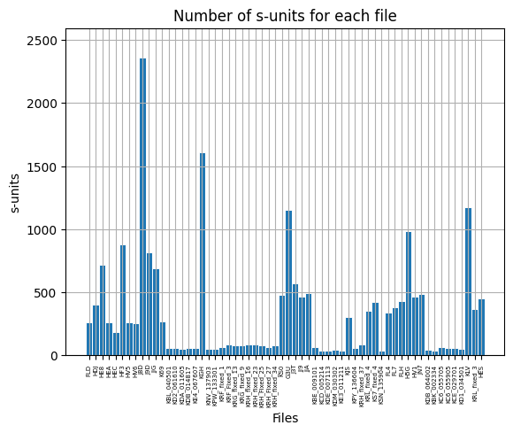

```python
bar_plot_function(DF_Files, DF_s_units, "Files", "s-units", "Number of s-units for each file")
```

# Graphs about the U-Units of all the corpus

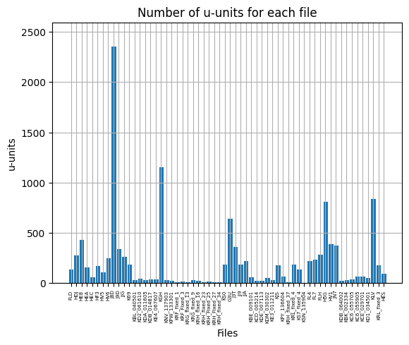

```python
bar_plot_function(DF_Files, DF_u_units, "Files", "u-units", "Number of u-units for each file")
```

# Graphs about the W-Units of all the corpus

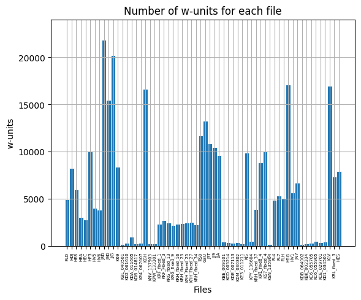

```python
bar_plot_function(DF_Files, DF_w_units, "Files", "w-units", "Number of w-units for each file")
```

# Number of speakers per files

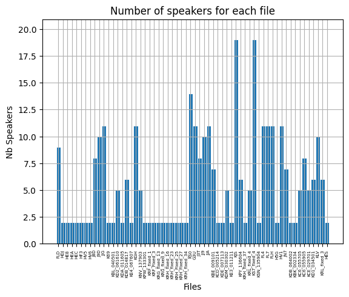

```python
bar_plot_function(DF_Files, DF_nb_speakers, "Files", "Nb Speakers", "Number of speakers for each file")
```